# AQI New Delhi_Aurisa Yusima

G1401231072 - Aurisa Putri Hawin Yusima

2025-09-18

### Inisialisasi Library dan Data

```r
library(dLagM)
library(nardl)
library(dynlm)
library(zoo)
library(base)
library(MLmetrics)
library(lmtest)
library(car)
dataset <- read.csv("E:/Kuliah/MPDW/Data/NewDelhi_Air_quality.csv")
head(dataset)
```

```
##   X  AQI       CO      datetime        no2       o3      pm10     pm25
## 1 0 30.2 198.6027 2022-10-21:18 0.04685717 55.78995 10.486722 5.637410
## 2 1 28.2 197.6013 2022-10-21:19 0.04645554 54.93164 10.719325 4.618169
## 3 2 26.6 198.6027 2022-10-21:20 0.04685717 54.64554 11.155578 3.520902
## 4 3 25.0 201.9405 2022-10-21:21 0.04819594 55.07469 11.116206 2.225919
## 5 4 26.0 205.2784 2022-10-21:22 0.04886533 55.78995 10.405250 1.979471
## 6 5 26.0 208.6163 2022-10-21:23 0.05020411 56.50520  9.402518 1.792677
##         so2     timestamp_local       timestamp_utc         ts
## 1 0.3874302 2022-10-21T23:00:00 2022-10-21T18:00:00 1666375200
## 2 0.4097819 2022-10-22T00:00:00 2022-10-21T19:00:00 1666378800
## 3 0.4023313 2022-10-22T01:00:00 2022-10-21T20:00:00 1666382400
## 4 0.3762543 2022-10-22T02:00:00 2022-10-21T21:00:00 1666386000
## 5 0.3390014 2022-10-22T03:00:00 2022-10-21T22:00:00 1666389600
## 6 0.3129244 2022-10-22T04:00:00 2022-10-21T23:00:00 1666393200
```

```r
str(dataset)
```

```
## 'data.frame':    72 obs. of  12 variables:
##  $ X              : int  0 1 2 3 4 5 6 7 8 9 ...
##  $ AQI            : num  30.2 28.2 26.6 25 26 26 26 24 23 24 ...
##  $ CO             : num  199 198 199 202 205 ...
##  $ datetime       : chr  "2022-10-21:18" "2022-10-21:19" "2022-10-21:20" "2022-10-21:21" ...
##  $ no2            : num  0.0469 0.0465 0.0469 0.0482 0.0489 ...
##  $ o3             : num  55.8 54.9 54.6 55.1 55.8 ...
##  $ pm10           : num  10.5 10.7 11.2 11.1 10.4 ...
##  $ pm25           : num  5.64 4.62 3.52 2.23 1.98 ...
##  $ so2            : num  0.387 0.41 0.402 0.376 0.339 ...
##  $ timestamp_local: chr  "2022-10-21T23:00:00" "2022-10-22T00:00:00" "2022-10-22T01:00:00" "2022-10-22T02:00:00" ...
##  $ timestamp_utc  : chr  "2022-10-21T18:00:00" "2022-10-21T19:00:00" "2022-10-21T20:00:00" "2022-10-21T21:00:00" ...
##  $ ts             : int  1666375200 1666378800 1666382400 1666386000 1666389600 1666393200 1666396800 1666400400 1666404000 1666407600 ...
```

```r
Y <- dataset$AQI
X <- dataset$o3
```

### Data Splitting

```r
train <- dataset[1:50, ]
test <- dataset[51:72, ]

train.ts <- ts(train)
test.ts  <- ts(test)
dataset.ts  <- ts(dataset)
```

```r
Yt <- train$AQI
Xt <- train$o3
```

```r
train$Xt <- train$o3
train$Yt <- train$AQI

test$Xt <- test$o3
test$Yt <- test$AQI
```

### Model Koyck

```r
model.koyck <- koyckDlm(x = Xt, y = Yt, intercept = TRUE)
summary(model.koyck)
```

```
##
## Call:
## "Y ~ (Intercept) + Y.1 + X.t"
##
## Residuals:
##       Min        1Q    Median        3Q       Max
## -1.151096 -0.263820  0.003836  0.244093  1.076568
##
## Coefficients:
##             Estimate Std. Error t value Pr(>|t|)
## (Intercept)  0.60533    0.94314   0.642    0.524
## Y.1          0.41624    0.08209   5.071 6.93e-06 ***
## X.t          0.25928    0.04101   6.322 9.52e-08 ***
## ---
## Signif. codes:  0 '***' 0.001 '**' 0.01 '*' 0.05 '.' 0.1 ' ' 1
##
## Residual standard error: 0.5094 on 46 degrees of freedom
## Multiple R-Squared: 0.9512,  Adjusted R-squared: 0.9491
## Wald test: 410.3 on 2 and 46 DF,  p-value: < 2.2e-16
##
## Diagnostic tests:
## NULL
##
##                             alpha      beta       phi
## Geometric coefficients:  1.036947 0.2592833 0.4162377
```

```r
AIC(model.koyck)
```

```
## [1] 77.85802
```

```r
BIC(model.koyck)
```

```
## [1] 85.4253
```

Peubah xt dan yt-1 memiliki nilai p-value < 0.05 yang menunukkan bahwa peubah xt dan yt-1 berpengaruh signifikan terhadap y.

### Forecasting

```r
length(test$Xt)
```

```
## [1] 22
```

```r
forecast.koyck <- forecast(model = model.koyck, x = test$Xt, h = 22)
forecast.koyck
```

```
## $forecasts
##  [1] 27.23642 27.52028 27.63843 27.50216 27.25998 26.78827 25.85011 24.53235
##  [9] 23.24203 22.05586 21.19122 20.27497 19.80086 20.06715 20.73436 21.01207
## [17] 21.12767 21.63942 23.15060 24.89234 26.35913 27.34057
##
## $call
## forecast.koyckDlm(model = model.koyck, x = test$Xt, h = 22)
##
## attr(,"class")
## [1] "forecast.koyckDlm" "dLagM"
```

```r
mape.koyck <- MAPE(forecast.koyck$forecasts, test$Yt)

mape.koyck
```

```
## [1] 0.02899356
```

```r
GoF(model.koyck)
```

```
##              n       MAE          MPE       MAPE      sMAPE      MASE      MSE
## model.koyck 49 0.3805309 -0.000502754 0.01419385 0.01416685 0.5854322 0.243606
##                  MRAE    GMRAE
## model.koyck 593606558 7877.206
```

Model Koyck yang dibangun memiliki tingkat akurasi yang sangat tinggi MAPE < 10% (MAPE 2.9%) dan error absolut (MAE) yang rendah menandakan bahwa model tersebut reliabel untuk forecasting

### Regression With distribution Lag

```r
model.dlm <- dlm(x = train$o3, y = train$AQI, q = 2)
summary(model.dlm)
```

```
##
## Call:
## lm(formula = model.formula, data = design)
##
## Residuals:
##      Min       1Q   Median       3Q      Max
## -0.44587 -0.36865 -0.05142  0.24389  1.38587
##
## Coefficients:
##               Estimate Std. Error t value Pr(>|t|)
## (Intercept) -0.0104664  0.7181482  -0.015    0.988
## x.t          0.4695153  0.0588098   7.984 4.26e-10 ***
## x.1         -0.0004461  0.1062228  -0.004    0.997
## x.2         -0.0073098  0.0582653  -0.125    0.901
## ---
## Signif. codes:  0 '***' 0.001 '**' 0.01 '*' 0.05 '.' 0.1 ' ' 1
##
## Residual standard error: 0.3583 on 44 degrees of freedom
## Multiple R-squared:  0.9768, Adjusted R-squared:  0.9752
## F-statistic:   618 on 3 and 44 DF,  p-value: < 2.2e-16
##
## AIC and BIC values for the model:
##       AIC     BIC
## 1 43.4975 52.8535
```

```r
AIC(model.dlm)
```

```
## [1] 43.4975
```

```r
BIC(model.dlm)
```

```
## [1] 52.8535
```

Terlihat hanya peubah Xt yang memiliki nilai p-value < 0.05 yang mana hal tersebut menunjukkan bahwa peubah Xt berpengaruh signifikan terhadap Yt.

```r
forecast.dlm <- forecast(model = model.dlm, x=test$Xt, h=22)
forecast.dlm
```

```
## $forecasts
##  [1] 27.40799 27.74349 27.73795 27.39689 27.06139 26.39529 25.05786 23.39048
##  [9] 22.06969 20.92173 20.27211 19.28358 19.12708 19.98249 20.99177 20.97775
## [17] 20.96206 21.80162 24.15159 26.15122 27.45600 28.09500
##
## $call
## forecast.dlm(model = model.dlm, x = test$Xt, h = 22)
##
## attr(,"class")
## [1] "forecast.dlm" "dLagM"
```

```r
mape.dlm <- MAPE(forecast.dlm$forecasts, test$Yt)
mape.dlm
```

```
## [1] 0.007853616
```

```r
GoF(model.dlm)
```

```
##            n      MAE           MPE       MAPE      sMAPE      MASE       MSE
## model.dlm 48 0.272788 -0.0001573495 0.01012354 0.01013572 0.4331431 0.1176534
##                 MRAE    GMRAE
## model.dlm 1026198781 8904.039
```

### Lag Optimum

```r
finiteDLMauto(formula = Yt ~ Xt,
              data = data.frame(train), q.min = 1, q.max = 10, model.type = "dlm", error.type = "AIC", trace = TRUE)
```

```
##    q - k    MASE      AIC      BIC     GMRAE   MBRAE R.Adj.Sq  Ljung-Box
## 10    10 0.34331 19.45847 41.41390 19619.244 0.50116  0.98539 0.46127017
## 5      5 0.37812 24.78482 39.23812  9355.450 0.49430  0.98434 0.20604139
## 3      3 0.40011 25.20655 36.30743  9729.294 0.49427  0.98359 0.12399990
## 4      4 0.39940 25.99508 38.79557 11892.043 0.49818  0.98350 0.19093971
## 9      9 0.38409 26.57473 47.13759 16265.748 0.50815  0.98315 0.95495240
## 8      8 0.39782 26.86728 45.98164 14081.125 0.51264  0.98407 0.50694285
## 6      6 0.37517 27.46132 43.51903  7156.215 0.48223  0.98378 0.21904550
## 7      7 0.38804 28.54189 46.15389  7928.706 0.48872  0.98375 0.38644874
## 2      2 0.43314 43.49750 52.85350  8904.039 0.48730  0.97524 0.09404448
## 1      1 0.51675 83.92339 91.49068  8190.926 0.40446  0.94238 0.16554905
```

### Pemodelan Lag Optimum

```r
model.dlm2 <- dlm(x = train$Xt,y = train$Yt , q = 5)
summary(model.dlm2)
```

```
##
## Call:
## lm(formula = model.formula, data = design)
##
## Residuals:
##      Min       1Q   Median       3Q      Max
## -0.50485 -0.24047  0.00149  0.24840  0.43159
##
## Coefficients:
##             Estimate Std. Error t value Pr(>|t|)
## (Intercept) -0.04504    0.70341  -0.064    0.949
## x.t          0.48313    0.04980   9.702 7.86e-12 ***
## x.1         -0.01836    0.10842  -0.169    0.866
## x.2          0.03375    0.12744   0.265    0.793
## x.3         -0.12396    0.12805  -0.968    0.339
## x.4          0.16898    0.10979   1.539    0.132
## x.5         -0.08164    0.05056  -1.615    0.115
## ---
## Signif. codes:  0 '***' 0.001 '**' 0.01 '*' 0.05 '.' 0.1 ' ' 1
##
## Residual standard error: 0.2903 on 38 degrees of freedom
## Multiple R-squared:  0.9865, Adjusted R-squared:  0.9843
## F-statistic: 461.9 on 6 and 38 DF,  p-value: < 2.2e-16
##
## AIC and BIC values for the model:
##        AIC      BIC
## 1 24.78482 39.23812
```

```r
AIC(model.dlm2)
```

```
## [1] 24.78482
```

```r
BIC(model.dlm2)
```

```
## [1] 39.23812
```

Terlihat hanya peubah Xt yang memiliki nilai p-value < 0.05 dan signifikan terhadap Yt.

```r
forecast.dlm2 <- forecast(model = model.dlm2, x=test$Xt, h=22)

mape.dlm2 <- MAPE(forecast.dlm2$forecasts, test$Yt)
```

```r
GoF(model.dlm2)
```

```
##             n       MAE           MPE        MAPE       sMAPE      MASE
## model.dlm2 45 0.2320274 -8.802781e-05 0.008534598 0.008530639 0.3781188
##                   MSE       MRAE   GMRAE
## model.dlm2 0.07117179 1077326062 9355.45
```

Model Distributed Lag yang dibangun memiliki tingkat akurasi yang sangat tinggi MAPE < 10% dan error absolut (MAE) yang rendah. Hal ini menandakan model cukup reliabel untuk forecasting.

### Model Autoregressive

```r
model.ardl <- ardlDlm(formula = Yt ~ Xt, data = train, p = 1, q = 1)
summary(model.ardl)
```

```
##
## Time series regression with "ts" data:
## Start = 2, End = 50
##
## Call:
## dynlm(formula = as.formula(model.text), data = data)
##
## Residuals:
##      Min       1Q   Median       3Q      Max
## -1.04103 -0.22727  0.08874  0.31201  0.82217
##
## Coefficients:
##             Estimate Std. Error t value Pr(>|t|)
## (Intercept) -0.16057    0.69764  -0.230    0.819
## Xt.t         0.47568    0.03699  12.861  < 2e-16 ***
## Xt.1        -0.22465    0.05027  -4.469 5.26e-05 ***
## Yt.1         0.46165    0.06907   6.684 3.01e-08 ***
## ---
## Signif. codes:  0 '***' 0.001 '**' 0.01 '*' 0.05 '.' 0.1 ' ' 1
##
## Residual standard error: 0.3881 on 45 degrees of freedom
## Multiple R-squared:  0.9723, Adjusted R-squared:  0.9704
## F-statistic: 526.3 on 3 and 45 DF,  p-value: < 2.2e-16
```

```r
AIC(model.ardl)
```

```
## [1] 52.13817
```

```r
BIC(model.ardl)
```

```
## [1] 61.59727
```

Terlihat peubah Xtm Xt-1, dan Yt-1 memiliki nilai p-value < 0.05 yang menunjukkan bahwa peubah-peubah tersebut berpengaruh signifikan terhadap Yt.

### Forecast

```r
forecast.ardl <- forecast(model.ardl, x=test$Xt, h=22)
forecast.ardl
```

```
## $forecasts
##  [1] 27.36726 27.71636 27.71683 27.37682 27.04031 26.36517 25.01394 23.33171
##  [9] 21.99759 20.83362 20.17819 19.17628 19.02568 19.88708 20.90373 20.89102
## [17] 20.88516 21.73303 24.10436 26.11570 27.44107 28.09066
##
## $call
## forecast.ardlDlm(model = model.ardl, x = test$Xt, h = 22)
##
## attr(,"class")
## [1] "forecast.ardlDlm" "dLagM"
```

```r
mape.ardl <- MAPE(forecast.ardl$forecasts, test$Yt)
mape.ardl
```

```
## [1] 0.00760396
```

```r
GoF(model.ardl)
```

```
##             n       MAE           MPE       MAPE      sMAPE      MASE       MSE
## model.ardl 49 0.3147603 -0.0001810141 0.01165475 0.01164238 0.4842467 0.1383575
##                  MRAE    GMRAE
## model.ardl 1133077109 8583.597
```

Model Autoregressive yang dibangun memiliki tingkat akurasi yang sangat tinggi MAPE < 10% sehingga menandakan model cukup reliabel untuk forecasting.

### Lag Optimum

```r
df <- data.frame(Yt = dataset$AQI, Xt = dataset$o3)
head(df)
```

```
##     Yt       Xt
## 1 30.2 55.78995
## 2 28.2 54.93164
## 3 26.6 54.64554
## 4 25.0 55.07469
## 5 26.0 55.78995
## 6 26.0 56.50520
```

```r
model.ardl.opt <- ardlBoundOrders(data = data.frame(df), ic = "AIC", formula = Yt ~ Xt)

model.ardl.opt
```

```
## $p
##   Xt
## 1 13
##
## $q
## [1] 2
##
## $Stat.table
##           q = 1    q = 2    q = 3    q = 4    q = 5    q = 6    q = 7    q = 8
## p = 1  38.64746 23.22848 25.42302 27.72031 28.70926 26.39158 27.98723 30.39158
## p = 2  22.86594 24.77455 27.31646 28.69429 28.81115 25.64963 27.33061 30.08845
## p = 3  27.18085 27.18085 28.84077 30.37243 30.71504 25.55412 27.74318 30.55048
## p = 4  27.27918 28.33392 28.33392 27.22651 29.94853 27.52594 29.31474 32.19458
## p = 5  28.22371 28.68011 29.37749 29.37749 30.12962 28.60210 31.06991 33.54724
## p = 6  27.11336 28.13965 27.00217 28.68077 28.68077 30.47844 33.06989 35.19285
## p = 7  30.19026 30.92504 29.24074 30.23773 30.81010 30.81010 29.56882 27.97012
## p = 8  26.81548 26.88306 26.96639 27.84677 26.80343 28.40155 28.40155 29.27146
## p = 9  25.15641 25.64777 25.75789 27.48094 26.12645 27.83358 29.58776 29.58776
## p = 10 28.59615 28.86775 29.29778 31.09265 28.82957 30.63888 32.57903 34.34994
## p = 11 24.53224 23.37847 24.80335 26.48648 23.35632 25.20746 26.60810 26.81938
## p = 12 27.14281 25.70395 27.06234 28.84787 26.03408 27.92602 28.91965 28.33033
## p = 13 19.25858 16.55044 18.53543 20.33824 17.61125 19.60705 21.03414 21.71506
## p = 14 20.31747 18.36045 20.36004 22.34912 19.16521 21.06710 22.41853 23.18530
## p = 15 22.41646 20.32505 22.22270 24.14701 21.64522 23.25026 24.97916 26.17790
##           q = 9   q = 10   q = 11   q = 12   q = 13   q = 14   q = 15
## p = 1  33.09252 33.18190 32.84415 33.19542 35.85663 30.71580 27.67083
## p = 2  32.80513 33.98671 32.34936 32.42167 35.04537 31.25200 27.25097
## p = 3  33.31925 34.28268 33.42041 33.94715 36.44309 32.48438 28.87461
## p = 4  34.95803 36.14844 35.27999 35.94335 38.39874 34.28870 30.56428
## p = 5  36.11311 37.41170 36.41377 37.18234 39.82841 36.17273 32.18350
## p = 6  35.88842 36.25737 35.13490 36.94569 39.67535 32.69633 29.29501
## p = 7  30.90878 33.89102 34.52801 36.37243 38.74818 31.23844 29.15791
## p = 8  31.44233 34.39275 26.01225 26.78247 27.92580 24.10080 23.75594
## p = 9  31.57509 33.98987 27.47278 26.92081 26.62574 21.91896 21.71187
## p = 10 34.34994 33.75383 24.46154 25.13892 26.98653 23.27262 23.65748
## p = 11 23.68447 23.68447 24.90968 27.13805 28.98636 25.18996 25.61717
## p = 12 25.59091 27.59091 27.59091 29.08999 29.84364 23.51211 22.55179
## p = 13 19.56880 19.27526 21.04212 21.04212 22.98266 23.87236 23.91841
## p = 14 22.81463 22.84285 24.84274 22.27955 22.27955 24.27951 25.89778
## p = 15 25.36264 24.86236 26.81668 26.73848 27.78117 27.78117 27.75060
##
## $min.Stat
## [1] 16.55044
```

```r
min_p=c()
for(i in 1:6){
  min_p[i]=min(model.ardl.opt$Stat.table[[i]])
}
q_opt=which(min_p==min(min_p, na.rm = TRUE))
p_opt=which(model.ardl.opt$Stat.table[[q_opt]] ==
              min(model.ardl.opt$Stat.table[[q_opt]], na.rm = TRUE))
data.frame("q_optimum" = q_opt, "p_optimum" = p_opt,
           "AIC"=model.ardl.opt$min.Stat)
```

```
##   q_optimum p_optimum      AIC
## 1         2        13 16.55044
```

Nilai AIC terendah didapat ketika p = 13 dan q = 2. Hal tersebut berarti model Autoregressive optimum didapat ketika p = 13 dan q = 2

### Pemodelan DLM dan ARDL

```r
#model dlm q=1
cons_lm1 <- dynlm(Yt ~ Xt+L(Xt),data = train.ts)

#model ardl p=1 q=0
cons_lm2 <- dynlm(Yt ~ Xt+L(Yt),data = train.ts)

#model ardl p=1 q=1
cons_lm3 <- dynlm(Yt ~ Xt+L(Xt)+L(Yt),data = train.ts)

#model dlm p=2
cons_lm4 <- dynlm(Yt ~ Xt+L(Xt)+L(Xt,2),data = train.ts)
```

```r
summary(cons_lm1)
```

```
##
## Time series regression with "ts" data:
## Start = 1, End = 50
##
## Call:
## dynlm(formula = Yt ~ Xt + L(Xt), data = train.ts)
##
## Residuals:
##     Min      1Q  Median      3Q     Max
## -0.6923 -0.4164 -0.1172  0.0953  4.2434
##
## Coefficients: (1 not defined because of singularities)
##             Estimate Std. Error t value Pr(>|t|)
## (Intercept)  1.30391    1.42962   0.912    0.366
## Xt           0.44188    0.02426  18.216   <2e-16 ***
## L(Xt)             NA         NA      NA       NA
## ---
## Signif. codes:  0 '***' 0.001 '**' 0.01 '*' 0.05 '.' 0.1 ' ' 1
##
## Residual standard error: 0.8169 on 48 degrees of freedom
## Multiple R-squared:  0.8736, Adjusted R-squared:  0.871
## F-statistic: 331.8 on 1 and 48 DF,  p-value: < 2.2e-16
```

```r
summary(cons_lm2)
```

```
##
## Time series regression with "ts" data:
## Start = 1, End = 50
##
## Call:
## dynlm(formula = Yt ~ Xt + L(Yt), data = train.ts)
##
## Residuals:
##        Min         1Q     Median         3Q        Max
## -6.755e-17 -4.127e-17 -2.345e-17  1.027e-17  2.113e-16
##
## Coefficients:
##              Estimate Std. Error   t value Pr(>|t|)
## (Intercept) 9.209e-16  1.152e-16 7.991e+00 2.63e-10 ***
## Xt          5.275e-17  5.454e-18 9.672e+00 9.28e-13 ***
## L(Yt)       1.000e+00  1.154e-17 8.669e+16  < 2e-16 ***
## ---
## Signif. codes:  0 '***' 0.001 '**' 0.01 '*' 0.05 '.' 0.1 ' ' 1
##
## Residual standard error: 6.529e-17 on 47 degrees of freedom
## Multiple R-squared:      1,  Adjusted R-squared:      1
## F-statistic: 2.973e+34 on 2 and 47 DF,  p-value: < 2.2e-16
```

```r
summary(cons_lm3)
```

```
##
## Time series regression with "ts" data:
## Start = 1, End = 50
##
## Call:
## dynlm(formula = Yt ~ Xt + L(Xt) + L(Yt), data = train.ts)
##
## Residuals:
##        Min         1Q     Median         3Q        Max
## -6.755e-17 -4.127e-17 -2.345e-17  1.027e-17  2.113e-16
##
## Coefficients: (1 not defined because of singularities)
##              Estimate Std. Error   t value Pr(>|t|)
## (Intercept) 9.209e-16  1.152e-16 7.991e+00 2.63e-10 ***
## Xt          5.275e-17  5.454e-18 9.672e+00 9.28e-13 ***
## L(Xt)              NA         NA        NA       NA
## L(Yt)       1.000e+00  1.154e-17 8.669e+16  < 2e-16 ***
## ---
## Signif. codes:  0 '***' 0.001 '**' 0.01 '*' 0.05 '.' 0.1 ' ' 1
##
## Residual standard error: 6.529e-17 on 47 degrees of freedom
## Multiple R-squared:      1,  Adjusted R-squared:      1
## F-statistic: 2.973e+34 on 2 and 47 DF,  p-value: < 2.2e-16
```

```r
summary(cons_lm4)
```

```
##
## Time series regression with "ts" data:
## Start = 1, End = 50
##
## Call:
## dynlm(formula = Yt ~ Xt + L(Xt) + L(Xt, 2), data = train.ts)
##
## Residuals:
##     Min      1Q  Median      3Q     Max
## -0.6923 -0.4164 -0.1172  0.0953  4.2434
##
## Coefficients: (2 not defined because of singularities)
##             Estimate Std. Error t value Pr(>|t|)
## (Intercept)  1.30391    1.42962   0.912    0.366
## Xt           0.44188    0.02426  18.216   <2e-16 ***
## L(Xt)             NA         NA      NA       NA
## L(Xt, 2)          NA         NA      NA       NA
## ---
## Signif. codes:  0 '***' 0.001 '**' 0.01 '*' 0.05 '.' 0.1 ' ' 1
##
## Residual standard error: 0.8169 on 48 degrees of freedom
## Multiple R-squared:  0.8736, Adjusted R-squared:  0.871
## F-statistic: 331.8 on 1 and 48 DF,  p-value: < 2.2e-16
```

### SSE

```r
deviance(cons_lm1)
```

```
## [1] 32.0323
```

```r
deviance(cons_lm2)
```

```
## [1] 2.003449e-31
```

```r
deviance(cons_lm3)
```

```
## [1] 2.003449e-31
```

```r
deviance(cons_lm4)
```

```
## [1] 32.0323
```

### Uji Encomptest

```r
any(is.na(coef(cons_lm1)))
```

```
## [1] TRUE
```

```r
any(is.na(coef(cons_lm2)))
```

```
## [1] FALSE
```

```r
any(is.na(coef(cons_lm3)))
```

```
## [1] TRUE
```

```r
any(is.na(coef(cons_lm4)))
```

```
## [1] TRUE
```

cons_lm2 tidak bisa diuji seperti model lainnya karena model pembandingnya mengandung NA

### Uji Autokorelasi Residual

```r
dwtest(cons_lm1)
```

```
##
##  Durbin-Watson test
##
## data:  cons_lm1
## DW = 0.52984, p-value < 2.2e-16
## alternative hypothesis: true autocorrelation is greater than 0
```

```r
dwtest(cons_lm2)
```

```
##
##  Durbin-Watson test
##
## data:  cons_lm2
## DW = 2.0416, p-value = 0.4557
## alternative hypothesis: true autocorrelation is greater than 0
```

```r
dwtest(cons_lm3)
```

[output not shown]

```r
dwtest(cons_lm4)
```

```
##
##  Durbin-Watson test
##
## data:  cons_lm4
## DW = 0.52984, p-value < 2.2e-16
## alternative hypothesis: true autocorrelation is greater than 0
```

### Uji Heteroskedastisitas

```r
bptest(cons_lm1)
```

```
##
##  studentized Breusch-Pagan test
##
## data:  cons_lm1
## BP = 1.0051, df = 1, p-value = 0.3161
```

```r
bptest(cons_lm2)
```

```
##
##  studentized Breusch-Pagan test
##
## data:  cons_lm2
## BP = 6.7694, df = 2, p-value = 0.03389
```

```r
bptest(cons_lm3)
```

```
##
##  studentized Breusch-Pagan test
##
## data:  cons_lm3
## BP = 6.7694, df = 2, p-value = 0.03389
```

```r
bptest(cons_lm4)
```

```
##
##  studentized Breusch-Pagan test
##
## data:  cons_lm4
## BP = 1.0051, df = 1, p-value = 0.3161
```

Ada indikasi heteroskedastisitas pada model cons_lm2 dan cons_lm 3

### Uji Normalitas

H0: Residual berdistribusi normal H1: Residual tidak berdistribusi normal

```r
shapiro.test(residuals(cons_lm1))
```

```
##
##  Shapiro-Wilk normality test
##
## data:  residuals(cons_lm1)
## W = 0.59799, p-value = 1.819e-10
```

```r
shapiro.test(residuals(cons_lm2))
```

```
##
##  Shapiro-Wilk normality test
##
## data:  residuals(cons_lm2)
## W = 0.81723, p-value = 2.239e-06
```

```r
shapiro.test(residuals(cons_lm3))
```

```
##
##  Shapiro-Wilk normality test
##
## data:  residuals(cons_lm3)
## W = 0.81723, p-value = 2.239e-06
```

```r
shapiro.test(residuals(cons_lm4))
```

```
##
##  Shapiro-Wilk normality test
##
## data:  residuals(cons_lm4)
## W = 0.59799, p-value = 1.819e-10
```

Seluruh modle terlihat memiliki residual yang tiak menyebar normal

### Perbandingan Model

```r
akurasi <- matrix(c(mape.koyck, mape.dlm, mape.dlm2, mape.ardl))
row.names(akurasi)<- c("Koyck","DLM 1","DLM 2","Autoregressive")
colnames(akurasi) <- c("MAPE")
akurasi
```

```
##                       MAPE
## Koyck          0.028993561
## DLM 1          0.007853616
## DLM 2          0.008220756
## Autoregressive 0.007603960
```

Model Autoregressive merupakan model paling optimum berdasarkan nilai MAPE terkecil

### Plot

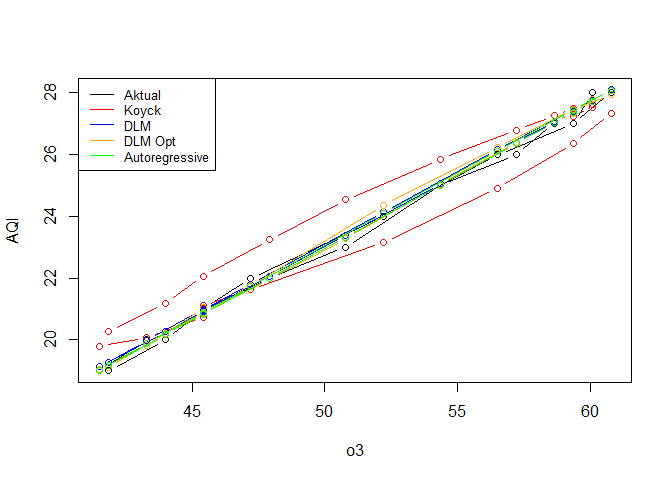

```r
plot(test$Xt, test$Yt, type="b", col="black", ylim=range(c(test$Yt,
                                                           forecast.koyck$forecasts,
                                                           forecast.dlm$forecasts,
                                                           forecast.dlm2$forecasts,
                                                           forecast.ardl$forecasts
                                                           )),
     xlab="o3", ylab="AQI")

lines(test$Xt, forecast.koyck$forecasts, col="red", type="b")
lines(test$Xt, forecast.dlm$forecasts, col="blue", type="b")
lines(test$Xt, forecast.dlm2$forecasts, col="orange", type="b")
lines(test$Xt, forecast.ardl$forecasts, col="green", type="b")


legend("topleft",
       legend=c("Aktual", "Koyck","DLM","DLM Opt","Autoregressive"),
       col=c("black","red","blue","orange","green"),
       lty=1, cex=0.8)
```

Semua model tampak mampu mengikuti tren data aktual.